# Tema 0 - Análisis de Datos

Roi Naveiro

2022-12-18

# ¿Qué es la Ciencia de Datos?

*“Data science is a concept to unify statistics, data analysis, machine learning and their related methods in order to **understand and analyze** actual phenomena with **data**. It employs techniques and theories drawn from many fields within the context of mathematics, statistics, information science, and computer science.”*

[Wikipedia](https://en.wikipedia.org/wiki/Data_science)

# ¿Qué es la Ciencia de Datos?

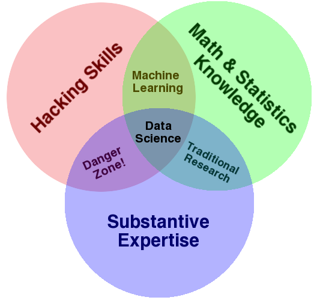

# ¿Qué son los Datos?

*“A collection of discrete units of information that in their most basic forms convey quantity, quality, fact, statistics, or other basic units of meaning.”*

[Wikipedia](https://en.wikipedia.org/wiki/Data)

¡Definición bastante vaga!

# Tipos de Datos

- Cualquier unidad de información es un dato
- Una distinción importante
  - Datos estructurados
  - Datos no estructurados

# Datos Estructurados

Datos tabulares

[figure not shown]

# Datos No Estructurados

Todo lo demás

- Imágenes
- Audio
- Vídeo
- Texto

# Tipos de Análisis de Datos

- Descriptivo
- Exploratorio
- Inferencial
- Predictivo
- Causal

# Análisis Descriptivo

**Objetivo**: resumir la información presente en un conjunto de datos

- Primer tipo de análisis de datos a realizar
- En general, las descripciones no se pueden generalizar sin la ayuda de modelos estadísticos

# Análisis Descriptivo

La base de datos `mtcars` de R contiene información extraída de la *1974 Motor Trend US magazine* acerca de 10 aspectos de diseño de rendimiento de 32 vehículos. La variable `am` se refiere a la transmisión (0 = automática, 1 = manual)

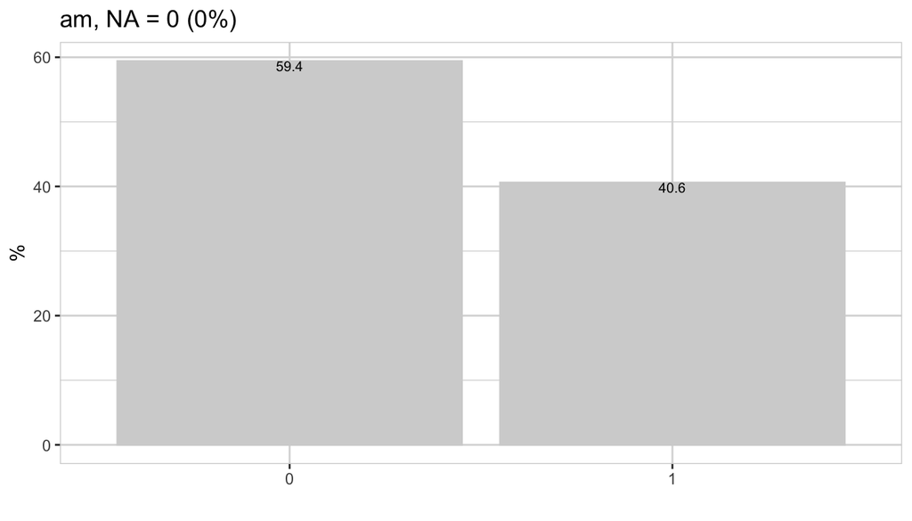

# Análisis Exploratorio

**Objetivo**: descubrir relaciones entre características de los datos

- Motiva preguntas de investigación

# Análisis Exploratorio

La variable `wt` se refiere al peso del vehículo y `mpg` a las millas por galón

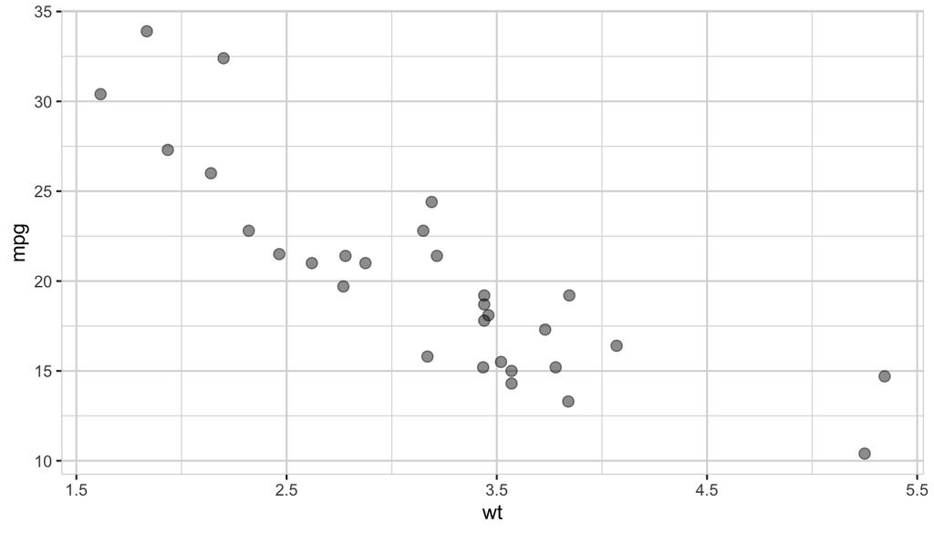

# Análisis Inferencial

**Objetivo**: usar una muestra pequeña de datos acerca de una población para extraer alguna información acerca de la misma.

- Aquí entra en juego la **estadística**

# Análisis Inferencial

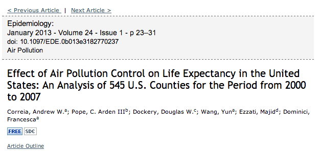

# Análisis Predictivo

**Objetivo**: utilizar datos sobre un conjunto de objetos para predecir el valor de una variable en un objeto nunca antes visto

- X predice Y no implica que X sea causa de Y

# Análisis Predictivo

[figure not shown]

[Fuente](https://www.r-bloggers.com/2020/11/time-series-demand-forecasting/)

# Análisis Causal

**Objetivo**: encontrar qué le sucede a una variable cuando se modifica el valor de otra

- Las relaciones causales usualmente identifican efectos medios, no efectos individuales

# Análisis Causal

[figure not shown]

# Este curso

Adentrarnos en la ciencia de datos a través de R

- Datos Tabulares (observacions x variables)
- Análisis Descriptivo, Exploratorio, Inferencial

Aprenderemos las herramientas fundamentales de R para las distintas fases de este esquema.

# Las fases de un proyecto de análisis de datos

1. **Importación**: cargar datos en R procedentes de: base de datos, fichero, aplicación web (API), etc.
2. **Organización**: almacenar datos de manera consistente con análisis.
3. **Transformación**: filtrado, creación de variables derivadas, etc.
4. **Visualización**: generación de preguntas, descubrimiento de tendencias.
5. **Análisis Exploratorio**: Visualización + tranformación aplicados de forma sistemática.
6. **Modelización**: confirmar hipótesis, responder preguntas.
7. **Comuniación**: comunicar resultados

# Las fases de un proyecto de análisis de datos

Todo esto usando el **lenguaje de programación R**.

# Programa

- Tema 1 - Programación en R
- Tema 2 - Análisis Exploratorio de los Datos
- Tema 3 - Data Wrangling
- Tema 4 - Modelización
- Tema 5 - Comunicación de resultados

# R y RStudio

### ¿Qué es R/RStudio?

- R es un lenguaje de programación especializacido en estadística
- RStudio es una interfaz para programar en R

[figure not shown]

[Instalación de R y RStudio](https://rstudio-education.github.io/hopr/starting.html)

# Presentación

- Análisis de Datos ECO-A
- Profesor: Roi Naveiro
- Email: roi.naveiro@cunef.edu
- Web del curso: https://roinaveiro.github.io/CU-analisis-datos/

# Horario

- *Horario clases*:
  - Lunes 15.30 - 16.30
  - Jueves 16.30 - 18.00
  - Viernes 16.30 - 18.00
- *Asistencia:* Obligatoria, al menos 80%

# Evaluación

- **Convocatoria Ordinaria**
  - Evaluación contínua: Examen 1: 20%
  - Evaluación contínua: Examen 2: 20%
  - Examen Ordinario Final: 60% (toda la materia)
- **Convocatoria Extraordinaria**: Examen Extraordinario Final (60%) + Evaluación contínua

# Recursos Interesantes

- [Análisis de datos acerca de la evolución de las tendencias musicales](https://towardsdatascience.com/billboard-hot-100-analytics-using-data-to-understand-the-shift-in-popular-music-in-the-last-60-ac3919d39b49)
- [A year as told by FitBit](https://livefreeordichotomize.com/2017/12/27/a-year-as-told-by-fitbit/)
- [Charla TED](https://www.youtube.com/watch?v=hVimVzgtD6w)
- [RMarkDown](https://www.rstudio.com/wp-content/uploads/2015/02/rmarkdown-cheatsheet.pdf)

# Bibliografía

- [Hands-On Programming with R](https://rstudio-education.github.io/hopr/), Grolemund (2014)
- [R for Data Science](https://r4ds.had.co.nz/), Wickham and Grolemund (2016)
- [Data Visualization, A practical introduction](https://socviz.co/), Healy (2018)
- [Data Science Specialization](https://github.com/DataScienceSpecialization/courses), Johns Hopkins University, Coursera